# Regression Diagnostics

Alexandra Chronopoulou

Lecture #9 Example

### Re-visit the Bike Shares Data to test the model assumptions

```r
bikeshares <-  read.csv("BikeShares.csv", header=TRUE)
dim(bikeshares)
head(bikeshares)
# We remove columns 1,  7, 8, 9, 10:
bikeshares.reg = bikeshares[,c(-1,-7,-8,-9,-10)]
head(bikeshares.reg)
```

We start by fitting the model that includes `temperature`, `humidity` and `wind_speed`.

```r
bikeshare.mlr = lm(cnt ~ t1 +  hum + wind_speed, data=bikeshares.reg )
```

### Checking Homoskedasticity

The residuals against fitted values plots can be obtained in two ways:

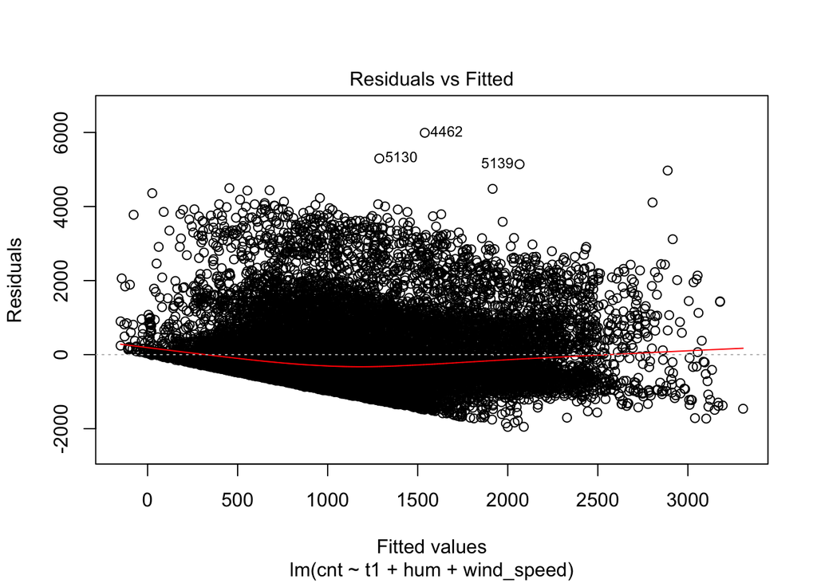

```r
plot(bikeshare.mlr, which=1)
```

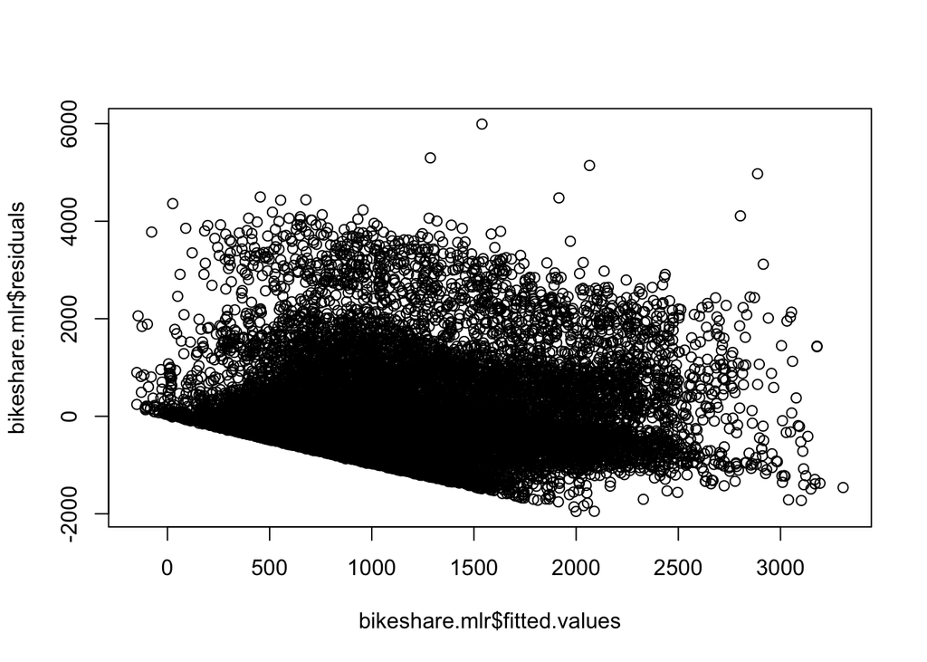

```r
plot(bikeshare.mlr$fitted.values, bikeshare.mlr$residuals)
```

We observe that the variance is probably not constant. Let’s perform a Breush-Pagan test:

```r
library(lmtest)
bptest(bikeshare.mlr)
```

```
##
##  studentized Breusch-Pagan test
##
## data:  bikeshare.mlr
## BP = 133.29, df = 3, p-value < 2.2e-16
```

We can also perform the BP test “by hand”:

```r
tmp.fit = lm(bikeshare.mlr$res^2 ~ t1 +  hum + wind_speed, data=bikeshares.reg )
summary(tmp.fit)$r.sq*dim(bikeshares.reg)[1]
```

```
## [1] 133.2861
```

The p-value of the test is very low, which means that we reject the null hypothesis of constant variace.

### Checking Normality

We start by looking at the QQ-plot and Histogram of the residuals:

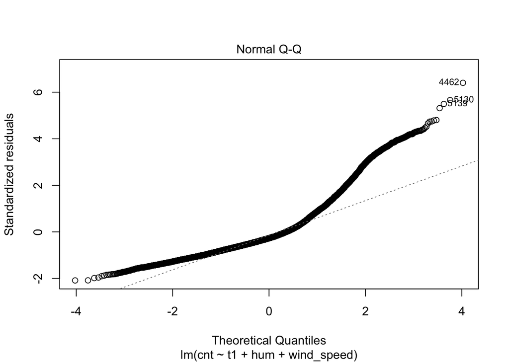

```r
plot(bikeshare.mlr, which=2)
```

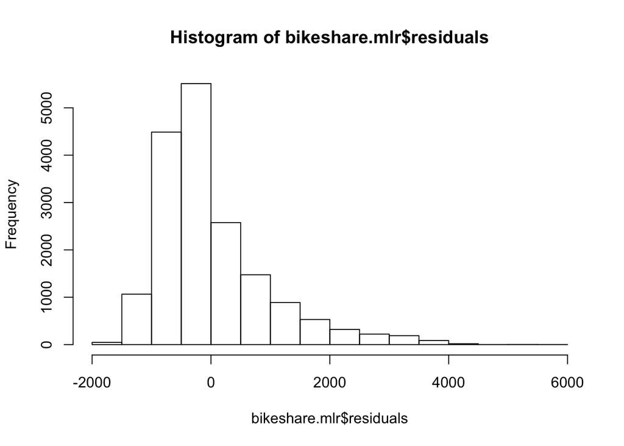

```r
hist(bikeshare.mlr$residuals)
```

The residuals are not normally distributed and from the histogram we can say that the distribution is right skewed. Outliers tend to skew the distribution of the residuals.

We also perform a hypothesis test to test the normality assumption. Recall that the Shapiro test only works when the sample size is less than 50. Here we use the Kolmogorov-Smirnov test:

```r
#shapiro.test(residuals(bikeshare.mlr))
```

```r
ks.test(residuals(bikeshare.mlr), y=pnorm)
```

```
##
##  One-sample Kolmogorov-Smirnov test
##
## data:  residuals(bikeshare.mlr)
## D = 0.63627, p-value < 2.2e-16
## alternative hypothesis: two-sided
```

The p-value is low, which implies that the normality assumption is not satisfied either.

### Checking the Linearity Assumption with Partial Regression Plots

The Partial Regression or Added Variable plots are used to check the model structure $E(\mathbf{y})=\mathbf{X}\beta$.

To create an added variables plot, we first regress the response (`cnt`) against all the predictors except for the one we need to test (`t1` here). Then, we regress the predictor we removed (`t1`) against the same predictors as before. Finally, we plot the residuals of the first regression against the residuals of the second regression.

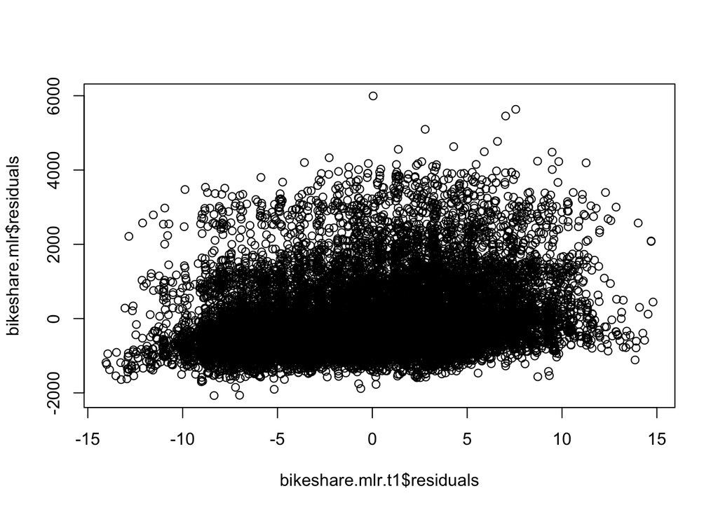

```r
bikeshare.mlr = lm(cnt ~   hum + wind_speed, data=bikeshares.reg )
bikeshare.mlr.t1 = lm(t1 ~   hum + wind_speed, data=bikeshares.reg )
plot(bikeshare.mlr.t1$residuals, bikeshare.mlr$residuals)
```

In the following code, we plot all added variables plots (including the one we just discussed):

```r
# The full model
g = lm(cnt ~ t1 +  hum + wind_speed, data=bikeshares.reg )

# t1 variable removed
r.yt1 = update(g, ~ hum + wind_speed)$res;
r.t1 = lm(t1 ~hum + wind_speed, data=bikeshares.reg)$res;
tmp1=lm(r.yt1 ~ r.t1);
summary(tmp1)
```

```
##
## Call:
## lm(formula = r.yt1 ~ r.t1)
##
## Residuals:
##     Min      1Q  Median      3Q     Max
## -1951.8  -602.0  -251.3   335.7  5991.9
##
## Coefficients:
##               Estimate Std. Error t value Pr(>|t|)
## (Intercept) -1.625e-13  7.093e+00    0.00        1
## r.t1         4.431e+01  1.424e+00   31.11   <2e-16 ***
## ---
## Signif. codes:  0 '***' 0.001 '**' 0.01 '*' 0.05 '.' 0.1 ' ' 1
##
## Residual standard error: 936 on 17412 degrees of freedom
## Multiple R-squared:  0.05267,    Adjusted R-squared:  0.05262
## F-statistic: 968.1 on 1 and 17412 DF,  p-value: < 2.2e-16
```

```r
# hum variable removed
r.yhum = update(g, ~ t1+wind_speed)$res;
r.hum = lm(hum ~ t1 + wind_speed, data=bikeshares.reg)$res;
tmp2=lm(r.yhum ~ r.hum);
summary(tmp2)
```

```
##
## Call:
## lm(formula = r.yhum ~ r.hum)
##
## Residuals:
##     Min      1Q  Median      3Q     Max
## -1951.8  -602.0  -251.3   335.7  5991.9
##
## Coefficients:
##               Estimate Std. Error t value Pr(>|t|)
## (Intercept) -2.466e-14  7.093e+00    0.00        1
## r.hum       -2.786e+01  5.727e-01  -48.65   <2e-16 ***
## ---
## Signif. codes:  0 '***' 0.001 '**' 0.01 '*' 0.05 '.' 0.1 ' ' 1
##
## Residual standard error: 936 on 17412 degrees of freedom
## Multiple R-squared:  0.1197, Adjusted R-squared:  0.1196
## F-statistic:  2367 on 1 and 17412 DF,  p-value: < 2.2e-16
```

```r
# wind_speed variable removed
r.ywin = update(g, ~ t1+hum)$res;
r.win = lm(wind_speed ~ t1 + hum, data=bikeshares.reg)$res;
tmp3=lm(r.ywin ~ r.win);
summary(tmp3)
```

```
##
## Call:
## lm(formula = r.ywin ~ r.win)
##
## Residuals:
##     Min      1Q  Median      3Q     Max
## -1951.8  -602.0  -251.3   335.7  5991.9
##
## Coefficients:
##               Estimate Std. Error t value Pr(>|t|)
## (Intercept) -1.453e-13  7.093e+00   0.000 1.000000
## r.win       -3.102e+00  9.384e-01  -3.306 0.000948 ***
## ---
## Signif. codes:  0 '***' 0.001 '**' 0.01 '*' 0.05 '.' 0.1 ' ' 1
##
## Residual standard error: 936 on 17412 degrees of freedom
## Multiple R-squared:  0.0006273,  Adjusted R-squared:  0.0005699
## F-statistic: 10.93 on 1 and 17412 DF,  p-value: 0.0009485
```

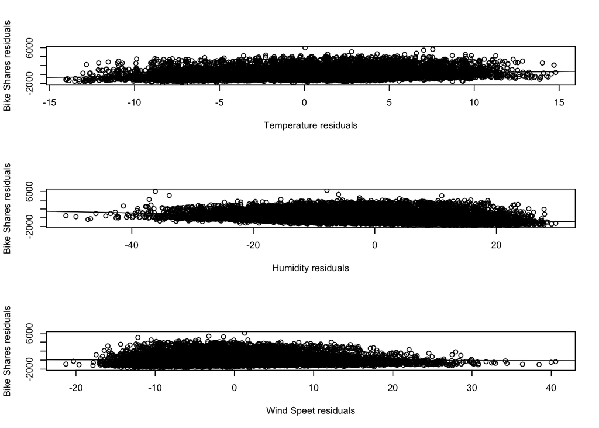

```r
# Added variables plots
par(mfrow=c(3,1))
plot(r.t1, r.yt1, xlab="Temperature residuals", ylab="Bike Shares residuals"); abline(tmp1)
plot(r.hum, r.yhum, xlab="Humidity residuals", ylab="Bike Shares residuals"); abline(tmp2)
plot(r.win, r.ywin, xlab="Wind Speet residuals", ylab="Bike Shares residuals"); abline(tmp3)
```

### Box Cox Transformations

In the lecture, we discussed that the Box-Cox method is looking for the optimal transformation of the response in a class of power transformations.

To do so, we can use the build-in `boxcox` function in the `MASS` package:

```r
library(MASS)
```

```r
#bikes.transformation = boxcox(bikeshare.mlr, lambda=seq(-2, 2, length=400))
```

If we run the `boxcox` function to the data set as is, we will run into trouble. IF we take a closer look at the data, we will find out that there is a zero value and we know that the `boxcox` method does not work for 0 or negative values. In our case, we only have a single 0 value, and no negative ones, so we can simply replace that 0 with a small positive quantity (a small epsilon term):

```r
min(bikeshares.reg$cnt) # this is the min value in the y's
```

```
## [1] 0
```

```r
which(bikeshares.reg$cnt==0) # this is the location of the min value
```

```
## [1] 2016
```

```r
bikeshares.reg$cnt[2016]=0.01 # we replace the min with a small positive value
min(bikeshares.reg$cnt) # we checke whether the 0 value was replaced by the small positive number
```

```
## [1] 0.01
```

Now, we are ready to apply the `boxcox` function:

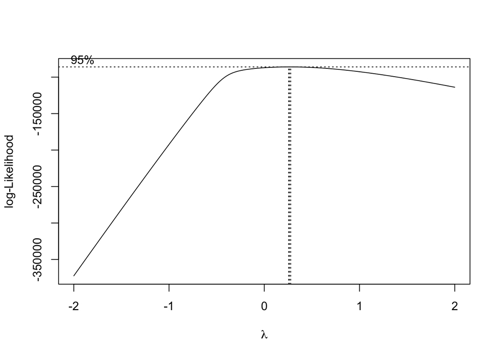

```r
bikes.transformation = boxcox(bikeshare.mlr, lambda=seq(-2, 2, length=400))
```

```r
names(bikes.transformation)
```

```
## [1] "x" "y"
```

```r
bikes.transformation$x[1:10]
```

```
##  [1] -2.000000 -1.989975 -1.979950 -1.969925 -1.959900 -1.949875 -1.939850
##  [8] -1.929825 -1.919799 -1.909774
```

```r
bikes.transformation$y[1:10]
```

```
##  [1] -372422.1 -370582.3 -368742.9 -366904.0 -365065.6 -363227.6 -361390.0
##  [8] -359553.0 -357716.4 -355880.2
```

```r
bikes.transformation$x[bikes.transformation$y == max(bikes.transformation$y)] # lambda.hat
```

```
## [1] 0.2656642
```

```r
tmp=bikes.transformation$x[bikes.transformation$y > max(bikes.transformation$y) - qchisq(0.95, 1)/2];

range(tmp) # 95% CI. Read Chapter 9 in the Faraway textbook for details.
```

```
## [1] 0.2556391 0.2756892
```

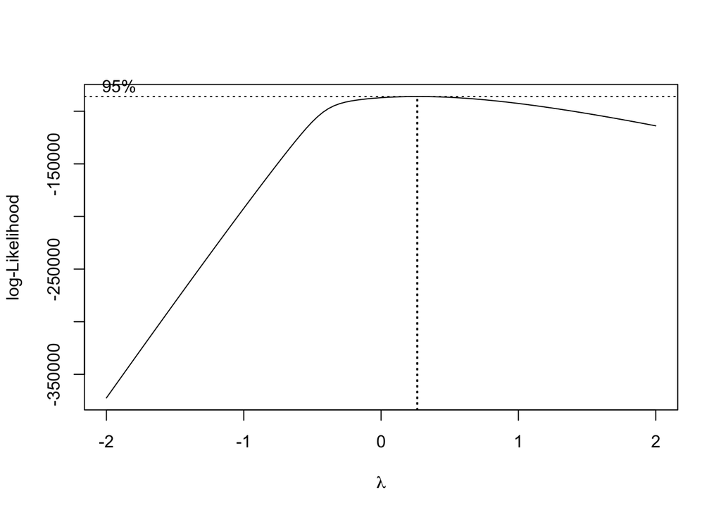

```r
boxcox(bikeshare.mlr,plotit=T) # plotit=T is the default setting
```

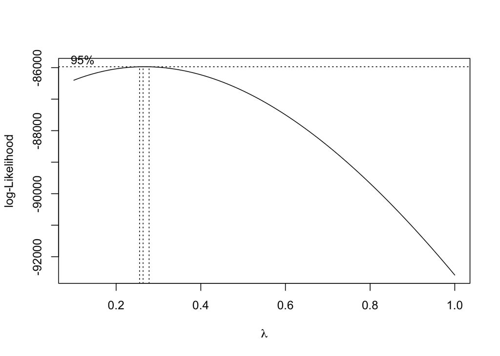

```r
boxcox(bikeshare.mlr,plotit=T,lambda=seq(0.1,1,by=0.05)) # zoom-in
```

We find that the optimal value is close to 0.27. We usually prefer to round the output of the boxcox function to make our interpretation easier. Since 0.27 is between the 0 (i.e. log transform) and 0.5 (i.e. square root transform), we can work with either of the transformations. We can also try both and see which one provides better results:

Let’s try to use the square roon (and you can try the other one at home)

```r
# Transform Y
bikeshares.reg$cnt.new = sqrt(bikeshares.reg$cnt)

bikeshare.mlr.new = lm(cnt.new ~ t1 +  hum + wind_speed, data=bikeshares.reg )
```

Let’s plot the diagnostic plots to see if we managed to fixed any of the issues:

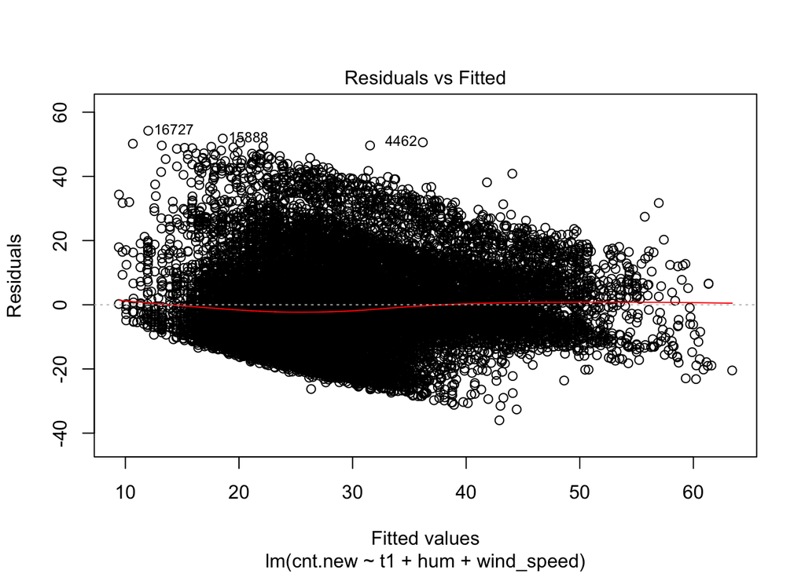

```r
plot(bikeshare.mlr.new, which=1)
```

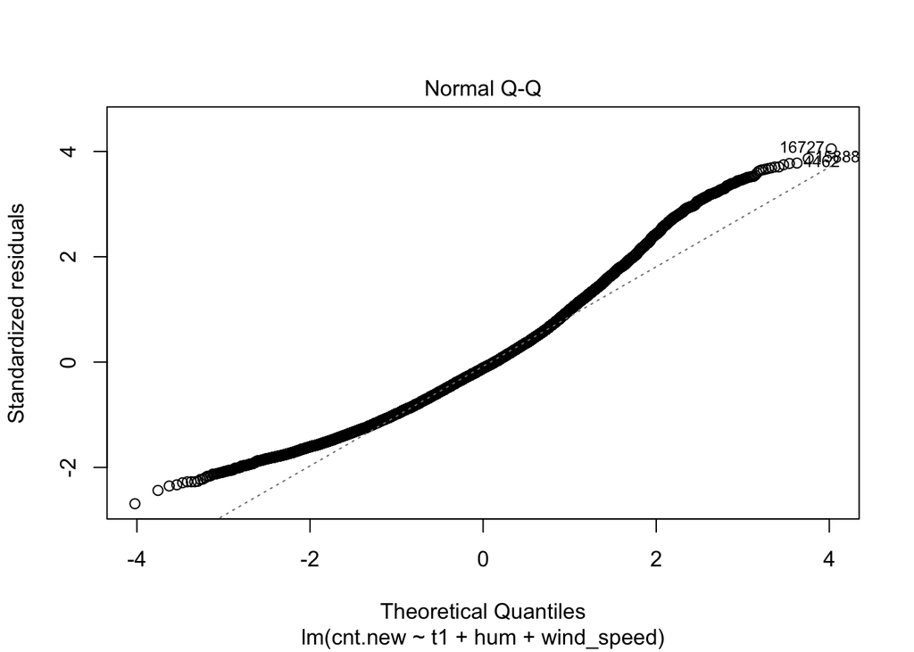

```r
plot(bikeshare.mlr.new, which=2)
```

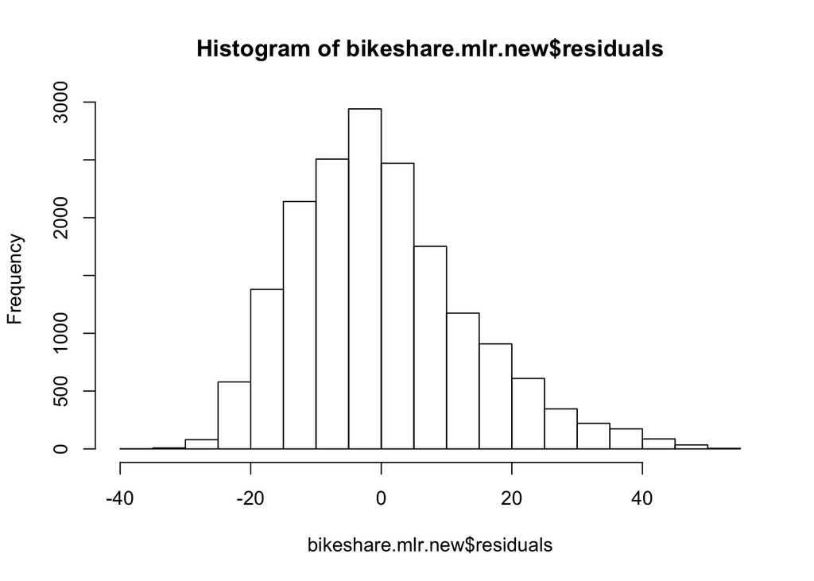

```r
hist(bikeshare.mlr.new$residuals)
```

```r
ks.test(residuals(bikeshare.mlr.new), y=pnorm)
```

```
##
##  One-sample Kolmogorov-Smirnov test
##
## data:  residuals(bikeshare.mlr.new)
## D = 0.46495, p-value < 2.2e-16
## alternative hypothesis: two-sided
```

Unfortunately, the constant variance and normality assumptions are still rejected, although the right tail of the residuals’ distribution is not as heavy as before.

*PRACTICE:* You can try to remove the influential points we identified in the previous lecture and test the assumptions again, use boxcox to see whether a better transformation is now available, apply that boxcox transform to the data and see what happens.

As we discussed, the assumptions may or may not be fixed. In large datasets like this one, the main problem might be that we have very few predictors to model the response. As we move on in the class, we will also discuss categorical predictors, so we will enrich our model and at the same time that might also improve the diagnostics of our new fitted model.

**Remark:** Every time that you fit a new model, you need to check the model assumptions from scratch - as you can observe all the tests are based on the residuals of the fitted model. So, if the model changes, the residuals and as a consequence the plots/test also change.